# Лабораторная работа №8

Операционные системы

Головко Екатерина Андреевна

1032252356@rudn.ru

Российский университет дружбы народов

2026-04-03

# Информация

## Докладчик

- Головко Екатерина Андреевна
- студент ФФМиЕН НБИ
- Российский университет дружбы народов им. П. Лумумбы
- 1032252356@rudn.ru
- https://eagolovko.github.io

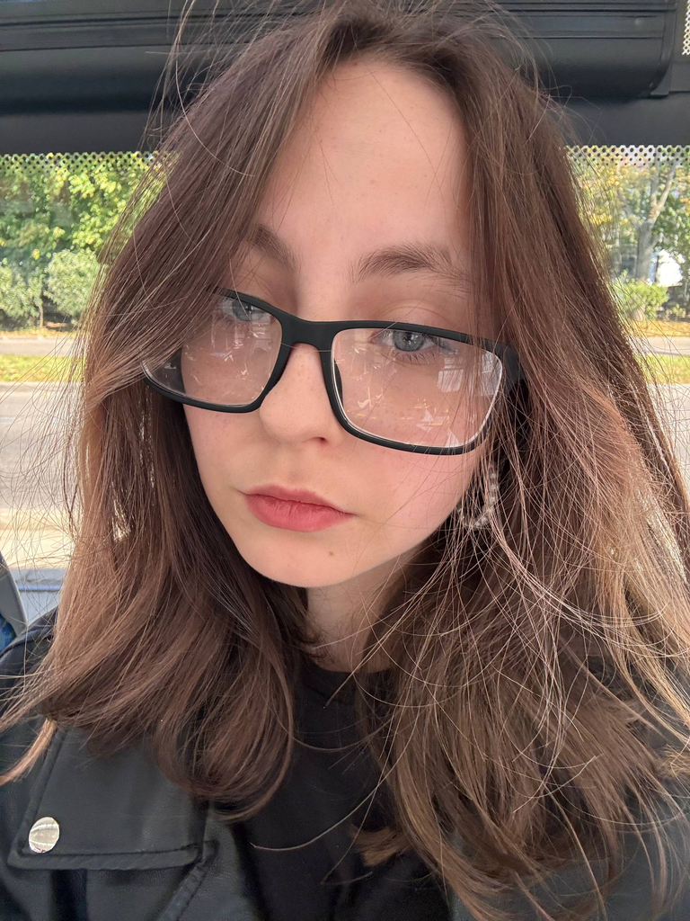

## Цель работы

Ознакомление с инструментами поиска файлов и фильтрации текстовых данных. Приобретение практических навыков: по управлению процессами (и заданиями), по проверку использования диска и обслуживанию файловых систем.

## Задание

1. Вход в систему
2. Записывание информации в файл и дописывание информации
3. Вывод имен файлов с определенным разрешением
4. Определение файлов, начинающихся с определенного символа
5. Выведение постранично на экран имен файлов
6. Запуск процесса в фоновом режиме
7. Удаление файла
8. Запуск редактора в фоновом режиме
9. Определение идентификатора процесса
10. Завершение процесса
11. Выполнение команд df и du
12. Вывод имен всех директорий домашнего каталога

# Выполнение лабораторной работы

## Задание №1

Вхожу в систему с нужным именем пользоватея и открываю терминал (рис. 1).

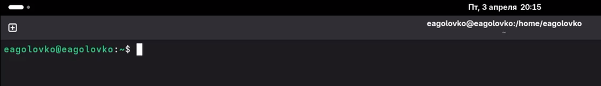

Рисунок 1

## Задание №2

Записываю в файл названия файлов, содержащихся в каталоге /etc. Затем дописываю в этот же файл названия файлов из домашнего каталога (рис. 2).

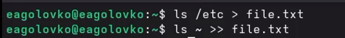

Рисунок 2

## Задание №2

Результат работы команд (рис. 3).

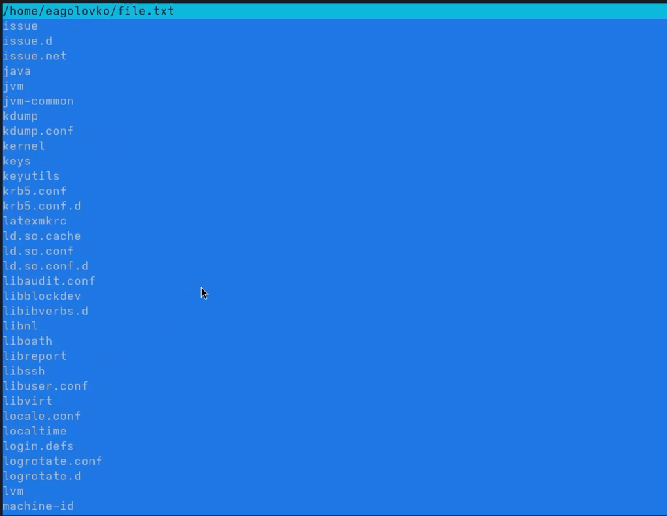

Рисунок 3: Результат

## Задание №3

Вывожу список имен файлов из file.txt, имеющих расширение .conf(рис. 4).

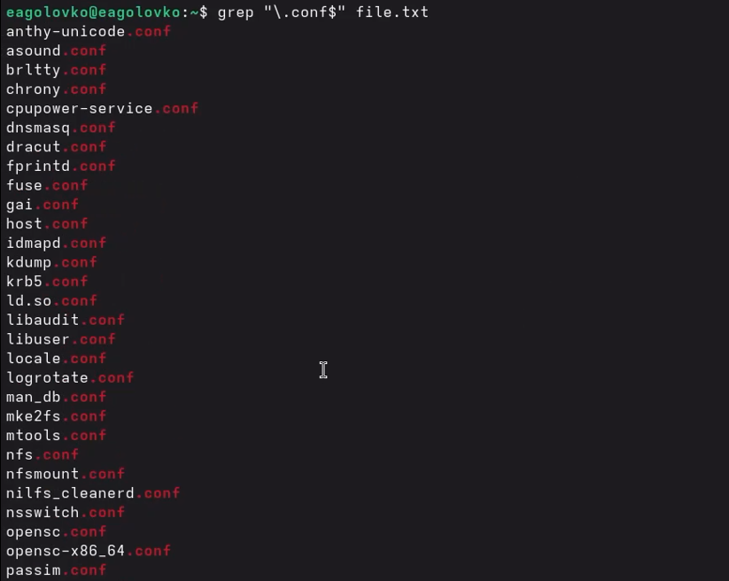

Рисунок 4: Вывод списка имен файлов

## Задание №3

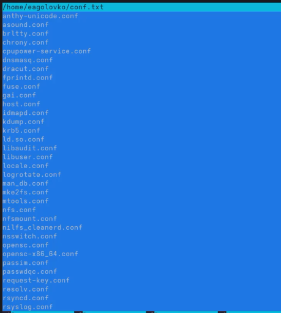

Рисунок 6: Результат

## Задание №4

Определяю, какие файлы в домашнем каталоге начинаются с символа с.

## Задание №4

2 вариант (рис. 8).

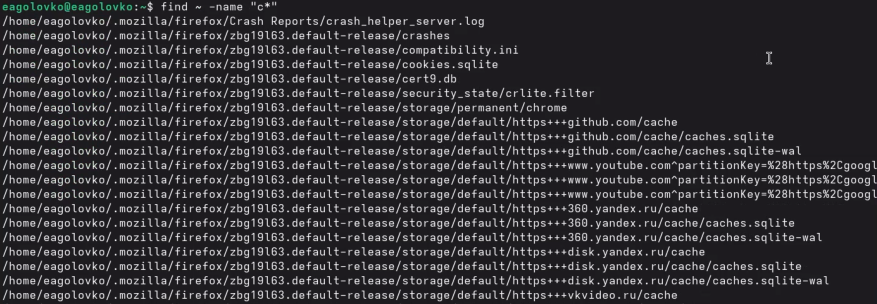

Рисунок 8: 2 вариант

## Задание №5

Результат (рис. 11).

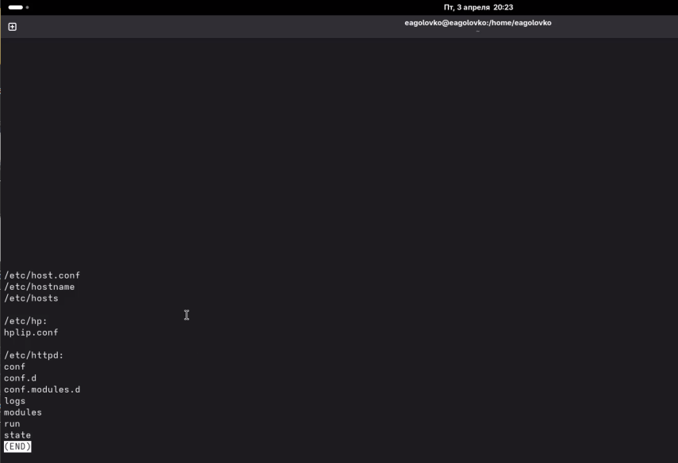

Рисунок 11: Результат

## Задание №9

Вывожу идентификатор процесса gedit(рис. 15).

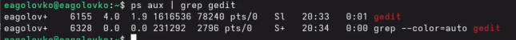

Рисунок 15: идентификатор процесса gedit

## Задание №10

Читаю справку по команде kill (рис. 17).

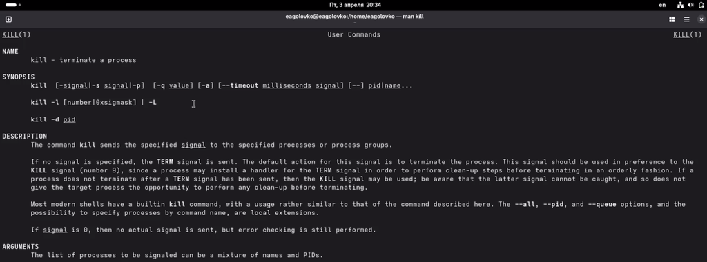

Рисунок 17: man kill

## Задание №10

Узнав нужную информацию, прерываю процесс с помощью этой команды (рис. 18).

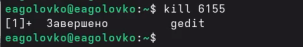

Рисунок 18: Прерывание процесса

## Задание №11

Читаю справку по команде df, она показывает информацию об использовании пространства файловой системы (рис. 19).

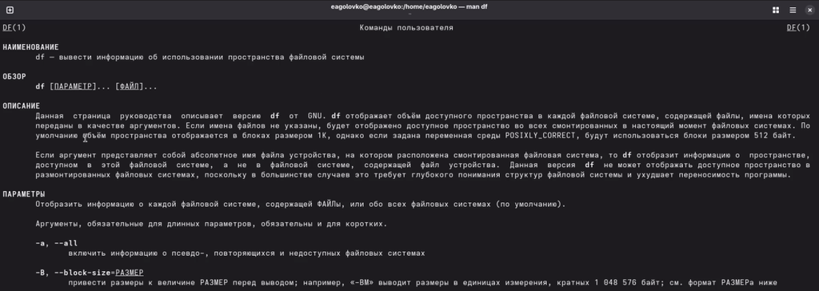

Рисунок 19: man df

## Задание №11

Результат этой команды (рис. 20).

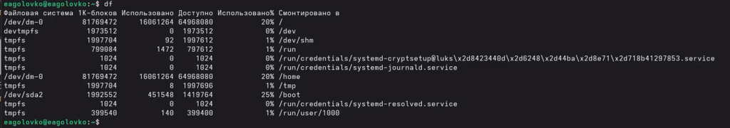

Рисунок 20: Результат

## Задание №11

Читаю справку по команде du, она оценивает используемое файлами пространство (рис. 21).

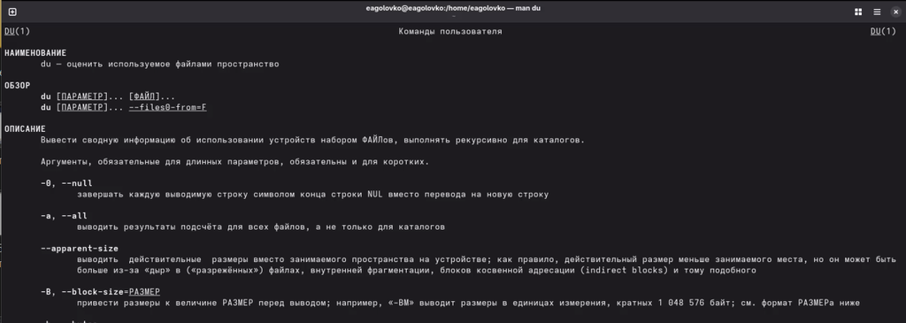

Рисунок 21: man du

## Задание №11

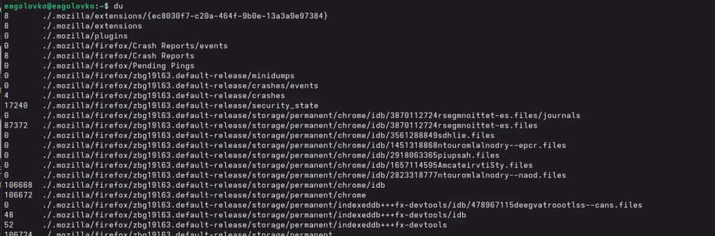

Рисунок 22: Результат

## Задание №12

Вывожу имена всех директорий из моего домашнего каталога (рис. 23).

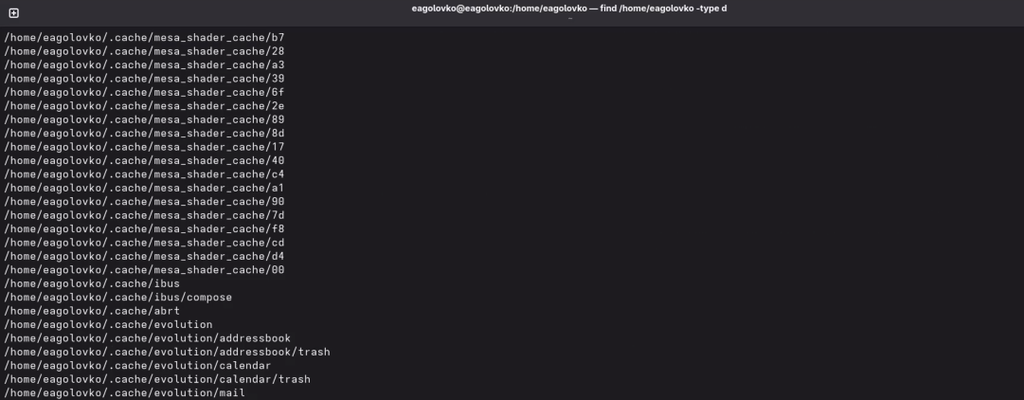

Рисунок 23: Имена всех директорий домашнего каталога

# Выводы

## Выводы

В ходе данной лабораторной работы я ознакомилась с инструментами поиска файлов и фильтрации текстовых данных, а также приобрела практические навыки по проверке использования диска, по управлению процессами и по обслуживанию файловых систем.